# Lineage Analysis of CRISPR and shRNA Screens

0.0471767

0.8627299

0.04718

NA

TNXB

bone cancer

0.0471767

0.8627299

0.04718

NA

TXNRD1

bone cancer

0.0471767

0.8627299

0.04718

NA

WBSCR16

multiple myeloma

0.0471767

0.8627299

0.04718

NA

WBSCR28

liver cancer

0.0471767

0.8627299

0.04718

NA

YTHDC1

liver cancer

0.0471767

0.8627299

0.04718

NA

ZFAT

liver cancer

0.0471767

0.8627299

0.04718

NA

ZNF253

multiple myeloma

0.0471767

0.8627299

0.04718

NA

ZNF768

liver cancer

0.0471767

0.8627299

0.04718

NA

PADI1

ovarian cancer

0.0474940

0.8627299

0.04749

NA

CLK4

uterine cancer

0.0475939

0.8627299

0.04759

NA

IFT172

uterine cancer

0.0476609

0.8627299

0.04766

NA

SNAPC4

colorectal cancer

0.0477287

0.8627299

0.04773

NA

SLC36A3

central nervous system cancer

0.0477802

0.8627299

0.04778

NA

UBE3A

uterine cancer

0.0478213

0.8627299

0.04782

NA

TRIM50

lung cancer

0.0478227

0.8627299

0.04782

NA

DENND4B

uterine cancer

0.0480312

0.8627299

0.04803

NA

ADAM15

leukemia

0.0480598

0.8627299

0.04806

NA

AK7

leukemia

0.0480598

0.8627299

0.04806

NA

BARD1

leukemia

0.0480598

0.8627299

0.04806

NA

CCDC65

leukemia

0.0480598

0.8627299

0.04806

NA

CCR10

leukemia

0.0480598

0.8627299

0.04806

NA

CENPT

leukemia

0.0480598

0.8627299

0.04806

NA

COL1A1

leukemia

0.0480598

0.8627299

0.04806

NA

CSF3R

leukemia

0.0480598

0.8627299

0.04806

NA

CSTF3

urinary bladder cancer

0.0480598

0.8627299

0.04806

NA

DHX38

urinary bladder cancer

0.0480598

0.8627299

0.04806

NA

DNAJB1

leukemia

0.0480598

0.8627299

0.04806

NA

DTNA

urinary bladder cancer

0.0480598

0.8627299

0.04806

NA

ESYT2

leukemia

0.0480598

0.8627299

0.04806

NA

FASTKD1

urinary bladder cancer

0.0480598

0.8627299

0.04806

NA

FOXG1

leukemia

0.0480598

0.8627299

0.04806

NA

GAB1

leukemia

0.0480598

0.8627299

0.04806

NA

GID4

leukemia

0.0480598

0.8627299

0.04806

NA

GPRIN1

leukemia

0.0480598

0.8627299

0.04806

NA

HIST1H1T

leukemia

0.0480598

0.8627299

0.04806

NA

HRH2

urinary bladder cancer

0.0480598

0.8627299

0.04806

NA

IL4I1

leukemia

0.0480598

0.8627299

0.04806

NA

ITPRIPL1

leukemia

0.0480598

0.8627299

0.04806

NA

JARID2

leukemia

0.0480598

0.8627299

0.04806

NA

KDM4C

leukemia

0.0480598

0.8627299

0.04806

NA

KIAA0825

urinary bladder cancer

0.0480598

0.8627299

0.04806

NA

LIM2

leukemia

0.0480598

0.8627299

0.04806

NA

MAP3K5

urinary bladder cancer

0.0480598

0.8627299

0.04806

NA

MAP4K3

urinary bladder cancer

0.0480598

0.8627299

0.04806

NA

MFSD5

leukemia

0.0480598

0.8627299

0.04806

NA

MSR1

leukemia

0.0480598

0.8627299

0.04806

NA

NOL4

urinary bladder cancer

0.0480598

0.8627299

0.04806

NA

NPAS4

leukemia

0.0480598

0.8627299

0.04806

NA

NXPE1

leukemia

0.0480598

0.8627299

0.04806

NA

OR5P3

urinary bladder cancer

0.0480598

0.8627299

0.04806

NA

P4HA1

urinary bladder cancer

0.0480598

0.8627299

0.04806

NA

PCDHGA8

leukemia

0.0480598

0.8627299

0.04806

NA

PHLDA2

leukemia

0.0480598

0.8627299

0.04806

NA

PPP1R13L

urinary bladder cancer

0.0480598

0.8627299

0.04806

NA

RPN1

urinary bladder cancer

0.0480598

0.8627299

0.04806

NA

SENP1

leukemia

0.0480598

0.8627299

0.04806

NA

SGK223

urinary bladder cancer

0.0480598

0.8627299

0.04806

NA

SLC30A4

leukemia

0.0480598

0.8627299

0.04806

NA

SORCS3

leukemia

0.0480598

0.8627299

0.04806

NA

STARD13

leukemia

0.0480598

0.8627299

0.04806

NA

STK3

leukemia

0.0480598

0.8627299

0.04806

NA

TBL1XR1

leukemia

0.0480598

0.8627299

0.04806

NA

TDRD1

leukemia

0.0480598

0.8627299

0.04806

NA

TGFB1

leukemia

0.0480598

0.8627299

0.04806

NA

TIMP4

leukemia

0.0480598

0.8627299

0.04806

NA

TMEM259

leukemia

0.0480598

0.8627299

0.04806

NA

TPO

leukemia

0.0480598

0.8627299

0.04806

NA

TRPC4

urinary bladder cancer

0.0480598

0.8627299

0.04806

NA

TUBA3C

leukemia

0.0480598

0.8627299

0.04806

NA

UGT8

leukemia

0.0480598

0.8627299

0.04806

NA

ZNF322

leukemia

0.0480598

0.8627299

0.04806

NA

ZNF541

leukemia

0.0480598

0.8627299

0.04806

NA

ZNF721

leukemia

0.0480598

0.8627299

0.04806

NA

KAT6B

central nervous system cancer

0.0480810

0.8627299

0.04808

NA

ZNF763

breast cancer

0.0481780

0.8627299

0.04818

NA

PKN1

skin cancer

0.0481834

0.8627299

0.04818

NA

CSMD2

uterine cancer

0.0483549

0.8627299

0.04835

NA

MYH14

central nervous system cancer

0.0483570

0.8627299

0.04836

NA

MTOR

uterine cancer

0.0483980

0.8627299

0.04840

NA

OR2T2

lung cancer

0.0484279

0.8627299

0.04843

NA

URB2

uterine cancer

0.0484640

0.8627299

0.04846

NA

AATK

breast cancer

0.0485396

0.8627299

0.04854

NA

ATP8B3

breast cancer

0.0485396

0.8627299

0.04854

NA

EXOC8

breast cancer

0.0485396

0.8627299

0.04854

NA

FAM160A2

breast cancer

0.0485396

0.8627299

0.04854

NA

FZD2

breast cancer

0.0485396

0.8627299

0.04854

NA

GP1BA

breast cancer

0.0485396

0.8627299

0.04854

NA

LIAS

breast cancer

0.0485396

0.8627299

0.04854

NA

MCF2L

breast cancer

0.0485396

0.8627299

0.04854

NA

MIER1

breast cancer

0.0485396

0.8627299

0.04854

NA

OR51A2

breast cancer

0.0485396

0.8627299

0.04854

NA

PLD2

breast cancer

0.0485396

0.8627299

0.04854

NA

PMPCA

breast cancer

0.0485396

0.8627299

0.04854

NA

PPP6R2

breast cancer

0.0485396

0.8627299

0.04854

NA

PREX1

breast cancer

0.0485396

0.8627299

0.04854

NA

PXDNL

breast cancer

0.0485396

0.8627299

0.04854

NA

PYGL

breast cancer

0.0485396

0.8627299

0.04854

NA

RAB5A

breast cancer

0.0485396

0.8627299

0.04854

NA

RAC1

breast cancer

0.0485396

0.8627299

0.04854

NA

SETD1B

breast cancer

0.0485396

0.8627299

0.04854

NA

URGCP

breast cancer

0.0485396

0.8627299

0.04854

NA

USP3

breast cancer

0.0485396

0.8627299

0.04854

NA

WNT5B

breast cancer

0.0485396

0.8627299

0.04854

NA

NOTCH3

uterine cancer

0.0486060

0.8627299

0.04861

NA

SYNE1

stomach cancer

0.0486182

0.8627299

0.04862

NA

HSPA8

lung cancer

0.0486256

0.8627299

0.04863

NA

ACSS1

uterine cancer

0.0486717

0.8627299

0.04867

NA

FDXR

uterine cancer

0.0486717

0.8627299

0.04867

NA

NBR1

uterine cancer

0.0486717

0.8627299

0.04867

NA

NFKBIZ

uterine cancer

0.0486717

0.8627299

0.04867

NA

PAN3

uterine cancer

0.0486717

0.8627299

0.04867

NA

DNAH3

leukemia

0.0487266

0.8627299

0.04873

NA

SETD1B

colorectal cancer

0.0487458

0.8627299

0.04875

NA

IFFO1

colorectal cancer

0.0488055

0.8627299

0.04881

NA

MAST4

lung cancer

0.0488533

0.8627299

0.04885

NA

PTH2R

lung cancer

0.0488533

0.8627299

0.04885

NA

CAMK2B

skin cancer

0.0489168

0.8627299

0.04892

NA

CCT6B

skin cancer

0.0489168

0.8627299

0.04892

NA

MDGA1

skin cancer

0.0489168

0.8627299

0.04892

NA

NLRP14

skin cancer

0.0489168

0.8627299

0.04892

NA

UNC13D

skin cancer

0.0489168

0.8627299

0.04892

NA

FLG2

lung cancer

0.0489732

0.8627299

0.04897

NA

NOD2

colorectal cancer

0.0489944

0.8627299

0.04899

NA

SAMD4A

colorectal cancer

0.0489944

0.8627299

0.04899

NA

SEMA3E

colorectal cancer

0.0489944

0.8627299

0.04899

NA

TMPRSS9

colorectal cancer

0.0489944

0.8627299

0.04899

NA

CLEC5A

colorectal cancer

0.0491408

0.8627299

0.04914

NA

ERCC5

colorectal cancer

0.0491408

0.8627299

0.04914

NA

GRB10

colorectal cancer

0.0491408

0.8627299

0.04914

NA

KNOP1

colorectal cancer

0.0491408

0.8627299

0.04914

NA

LGI3

colorectal cancer

0.0491408

0.8627299

0.04914

NA

MERTK

colorectal cancer

0.0491408

0.8627299

0.04914

NA

OR1M1

colorectal cancer

0.0491408

0.8627299

0.04914

NA

RBBP9

colorectal cancer

0.0491408

0.8627299

0.04914

NA

RGS3

colorectal cancer

0.0491408

0.8627299

0.04914

NA

SGIP1

colorectal cancer

0.0491408

0.8627299

0.04914

NA

SRSF6

colorectal cancer

0.0491408

0.8627299

0.04914

NA

TOR1AIP2

colorectal cancer

0.0491408

0.8627299

0.04914

NA

ZNF165

colorectal cancer

0.0491408

0.8627299

0.04914

NA

CD109

uterine cancer

0.0493634

0.8627299

0.04936

NA

AMACR

uterine cancer

0.0494514

0.8627299

0.04945

NA

BPTF

cancer

0.0494514

0.8627299

0.04945

NA

CCDC83

uterine cancer

0.0494514

0.8627299

0.04945

NA

HK1

uterine cancer

0.0494514

0.8627299

0.04945

NA

MCTP1

uterine cancer

0.0494514

0.8627299

0.04945

NA

MYZAP

uterine cancer

0.0494514

0.8627299

0.04945

NA

SLC6A9

uterine cancer

0.0494514

0.8627299

0.04945

NA

SMG8

uterine cancer

0.0494514

0.8627299

0.04945

NA

TRAPPC10

uterine cancer

0.0494514

0.8627299

0.04945

NA

GATAD1

lung cancer

0.0494908

0.8627299

0.04949

NA

PALLD

lung cancer

0.0494908

0.8627299

0.04949

NA

ZNRF3

lung cancer

0.0494908

0.8627299

0.04949

NA

GLI3

colorectal cancer

0.0495911

0.8627299

0.04959

NA

MYH9

colorectal cancer

0.0495911

0.8627299

0.04959

NA

FAM209A

colorectal cancer

0.0496715

0.8627299

0.04967

NA

GRK7

colorectal cancer

0.0496715

0.8627299

0.04967

NA

PIK3CB

colorectal cancer

0.0496715

0.8627299

0.04967

NA

SETD2

colorectal cancer

0.0496715

0.8627299

0.04967

NA

CHUK

pancreatic cancer

0.0496842

0.8627299

0.04968

NA

ABCA12

colorectal cancer

0.0496897

0.8627299

0.04969

NA

MYO9B

colorectal cancer

0.0496897

0.8627299

0.04969

NA

SF3B2

leukemia

0.0497800

0.8627299

0.04978

NA

MYO7B

lung cancer

0.0498087

0.8627299

0.04981

NA

GTSE1

lung cancer

0.0498556

0.8627299

0.04986

NA

NYNRIN

skin cancer

0.0498690

0.8627299

0.04987

NA

OR4S2

lung cancer

0.0498857

0.8627299

0.04989

NA

TRIP11

peripheral nervous system neoplasm

0.0499735

0.8627299

0.04997

NA

Note:

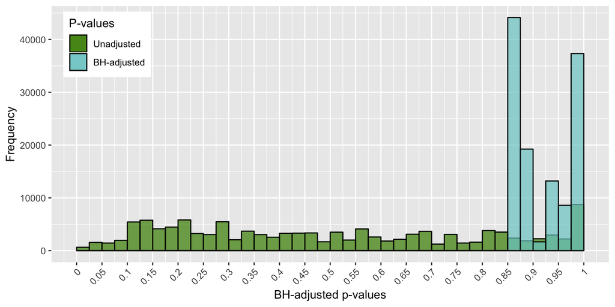

```r
wilcox_gene_delmis_lineage_plot <- ggplot(data = crispr_signif_delmis_lineage) +
  geom_histogram(aes(x = p, fill = "chartreuse4"), breaks = seq(0, 1, by = 0.025), color = "black", alpha = 0.7) +
  geom_histogram(aes(x = p.adj, fill = "darkslategray3"), breaks = seq(0, 1, by = 0.025), color = "black", alpha = 0.7) +
  scale_x_continuous(breaks = seq(0, 1, by = 0.05), labels = seq(0, 1, by = 0.05)) +
  # coord_cartesian(ylim = c(0, 3500)) +
  # scale_y_continuous(breaks = seq(0, 3500, by = 500), labels = formatC(seq(0, 3500, by = 500), format = "d")) +
  scale_fill_manual(name = "P-values", values = c("chartreuse4" = "chartreuse4", "darkslategray3" = "darkslategray3"), labels = c("Unadjusted", "BH-adjusted")) +
  theme(axis.text.x = element_text(angle = 45, hjust = 1), legend.position = c(0.1, 0.85)) +
  labs(x = "BH-adjusted p-values", y = "Frequency")
wilcox_gene_delmis_lineage_plot
```

## 4.3 Grouped by gene and tissue

### 4.3.1 Deleterious vs. Other

```r
crispr_signif_del_tissue <- compare_means(Score ~ Mutation_Status_Deleterious, group.by = c("Hugo_Symbol", "primary_tissue"), data = crispr_data, method = "wilcox.test", p.adjust.method = "BH")
crispr_signif_del_tissue <- adj_signif(crispr_signif_del_tissue)
crispr_signif_del_tissue <- crispr_signif_del_tissue[order(crispr_signif_del_tissue$p),]
saveRDS(crispr_signif_del_tissue, "./data_munging/rds/crispr_signif_deleterious_tissue.rds")

# write.table(crispr_signif_del_tissue, file = "~/Desktop/crispr_signif_deleterious_tissue.csv", quote = FALSE, sep = ",", row.names = FALSE)
```

```r
crispr_signif_del_tissue <- readRDS("./data_munging/rds/crispr_signif_deleterious_tissue.rds")

knitr::kable(filter(crispr_signif_del_tissue, p < 0.05)[, c("Hugo_Symbol", "primary_tissue", "p", "p.adj", "p.format", "p.signif", "p.signif.adj")], caption = "Wilcoxon test results comparing deleterious mutant and other cell lines by tissue, p < 0.05 (BH-adjusted p-values: * p <= 0.05, ** p <= 0.01, *** p <= 0.001, **** p <= 0.0001)") %>% kable_styling(bootstrap_options = c("striped", "hover", "condensed", "responsive")) %>% footnote(general = "Wilcoxon test Benjamini-Hochberg-corrected p-values:\n*: p <= 0.05\n**: p <= 0.01\n***: p <= 0.001\n****: p <= 0.0001") %>% scroll_box(width = "900px", height = "450px")
```

Wilcoxon test results comparing deleterious mutant and other cell lines by tissue, p < 0.05 (BH-adjusted p-values: * p <= 0.05, ** p <= 0.01, *** p <= 0.001, **** p <= 0.0001)

Hugo_Symbol

primary_tissue

p

p.adj

p.format

p.signif

p.signif.adj

PTEN

central_nervous_system

0.0004997

0.8270235

0.0005

***

NA

IFIT1B

lung

0.0015901

0.8270235

0.0016

NA

TP53

lung

0.0024143

0.8270235

0.0024

NA

DCAF8

lung

0.0031624

0.8270235

0.0032

NA

ZNF141

central_nervous_system

0.0033968

0.8270235

0.0034

NA

PTEN

ovary

0.0046087

0.8270235

0.0046

NA

ARID1B

ovary

0.0050278

0.8270235

0.0050

NA

IFT122

lung

0.0057958

0.8270235

0.0058

NA

SETD2

kidney

0.0059595

0.8270235

0.0060

NA

KRT17

breast

0.0063661

0.8270235

0.0064

NA

ZNF343

lung

0.0063770

0.8270235

0.0064

NA

DVL2

uterus

0.0067676

0.8270235

0.0068

NA

ARID1A

pancreas

0.0076726

0.8270235

0.0077

NA

COX4I1

lung

0.0099605

0.8270235

0.0100

NA

TPR

lung

0.0103031

0.8270235

0.0103

NA

SMARCA4

lung

0.0109819

0.8270235

0.0110

NA

ALPPL2

ovary

0.0109961

0.8270235

0.0110

NA

ATRNL1

lung

0.0110548

0.8270235

0.0111

NA

PLOD3

colorectal

0.0114716

0.8270235

0.0115

NA

SCN10A

uterus

0.0119017

0.8270235

0.0119

NA

DOPEY2

colorectal

0.0120018

0.8270235

0.0120

NA

KMT2B

gastric

0.0132674

0.8270235

0.0133

NA

PPP3R1

skin

0.0134888

0.8270235

0.0135

NA

DDC

uterus

0.0137273

0.8270235

0.0137

NA

ST5

uterus

0.0147587

0.8270235

0.0148

NA

KRT19

urinary_tract

0.0166681

0.8270235

0.0167

NA

DENND1B

uterus

0.0168725

0.8270235

0.0169

NA

GATS

ovary

0.0175485

0.8270235

0.0175

NA

RB1

central_nervous_system

0.0175650

0.8270235

0.0176

NA

ZCCHC24

lung

0.0175868

0.8270235

0.0176

NA

C11orf57

uterus

0.0178172

0.8270235

0.0178

NA

TIMD4

uterus

0.0178172

0.8270235

0.0178

NA

MEGF8

colorectal

0.0183515

0.8270235

0.0184

NA

CALCRL

lung

0.0195739

0.8270235

0.0196

NA

PDE1A

lung

0.0195739

0.8270235

0.0196

NA

NCOR1

uterus

0.0197808

0.8270235

0.0198

NA

JMJD1C

kidney

0.0198271

0.8270235

0.0198

NA

ZNF326

upper_aerodigestive

0.0198271

0.8270235

0.0198

NA

ANKRD11

central_nervous_system

0.0199067

0.8270235

0.0199

NA

ECT2L

central_nervous_system

0.0207079

0.8270235

0.0207

NA

KMT2D

lung

0.0208226

0.8270235

0.0208

NA

PRDM2

colorectal

0.0208898

0.8270235

0.0209

NA

EGFR

lung

0.0212897

0.8270235

0.0213

NA

LILRB2

leukemia

0.0212979

0.8270235

0.0213

NA

DENND4B

uterus

0.0213185

0.8270235

0.0213

NA

ESRP1

uterus

0.0213911

0.8270235

0.0214

NA

AKR1C1

lung

0.0216855

0.8270235

0.0217

NA

UGT2A3

lung

0.0216855

0.8270235

0.0217

NA

ZNRF3

lung

0.0216855

0.8270235

0.0217

NA

RALGAPB

uterus

0.0222505

0.8270235

0.0223

NA

THADA

colorectal

0.0226230

0.8270235

0.0226

NA

UBN2

lung

0.0228171

0.8270235

0.0228

NA

FER

colorectal

0.0228475

0.8270235

0.0228

NA

AXIN1

ovary

0.0232598

0.8270235

0.0233

NA

B4GALNT3

colorectal

0.0233134

0.8270235

0.0233

NA

COG6

colorectal

0.0233134

0.8270235

0.0233

NA

HAX1

colorectal

0.0233134

0.8270235

0.0233

NA

TAF3

colorectal

0.0233134

0.8270235

0.0233

NA

WDR46

colorectal

0.0233134

0.8270235

0.0233

NA

DAZAP1

uterus

0.0233796

0.8270235

0.0234

NA

MAP3K2

central_nervous_system

0.0234650

0.8270235

0.0235

NA

WDR87

leukemia

0.0236477

0.8270235

0.0236

NA

ANXA4

breast

0.0237414

0.8270235

0.0237

NA

ARHGDIB

lung

0.0239927

0.8270235

0.0240

NA

ABCC5

multiple_myeloma

0.0240966

0.8270235

0.0241

NA

NUP205

uterus

0.0243902

0.8270235

0.0244

NA

RYR2

colorectal

0.0246475

0.8270235

0.0246

NA

PABPC1

pancreas

0.0246982

0.8270235

0.0247

NA

NRG3

lung

0.0250099

0.8270235

0.0250

NA

DLGAP5

uterus

0.0252831

0.8270235

0.0253

NA

EPB41L5

uterus

0.0252831

0.8270235

0.0253

NA

KRT16

upper_aerodigestive

0.0253105

0.8270235

0.0253

NA

GSPT1

colorectal

0.0257186

0.8270235

0.0257

NA

ZNF292

colorectal

0.0257186

0.8270235

0.0257

NA

PPP1R12A

central_nervous_system

0.0260428

0.8270235

0.0260

NA

SKAP1

lung

0.0262660

0.8270235

0.0263

NA

NF1

peripheral_nervous_system

0.0263202

0.8270235

0.0263

NA

KIAA1755

lung

0.0265098

0.8270235

0.0265

NA

REG1B

lung

0.0265098

0.8270235

0.0265

NA

SRPK2

lung

0.0265098

0.8270235

0.0265

NA

ZNF230

urinary_tract

0.0266603

0.8270235

0.0267

NA

DNAJC13

lung

0.0270271

0.8270235

0.0270

NA

EIF2AK3

kidney

0.0274105

0.8270235

0.0274

NA

KRT19

bone

0.0274105

0.8270235

0.0274

NA

EDNRB

uterus

0.0277385

0.8270235

0.0277

NA

GYPE

skin

0.0281858

0.8270235

0.0282

NA

CACYBP

uterus

0.0283176

0.8270235

0.0283

NA

KRTAP10-6

uterus

0.0283176

0.8270235

0.0283

NA

RPL14

uterus

0.0283176

0.8270235

0.0283

NA

ADAM15

leukemia

0.0283870

0.8270235

0.0284

NA

AK7

leukemia

0.0283870

0.8270235

0.0284

NA

MAP9

bone

0.0283870

0.8270235

0.0284

NA

ZNF581

leukemia

0.0283870

0.8270235

0.0284

NA

COL11A1

lung

0.0288671

0.8270235

0.0289

NA

BRD8

lung

0.0292519

0.8270235

0.0293

NA

TTF1

lung

0.0292519

0.8270235

0.0293

NA

DOPEY1

colorectal

0.0293818

0.8270235

0.0294

NA

AGO4

uterus

0.0294387

0.8270235

0.0294

NA

CCDC83

uterus

0.0294387

0.8270235

0.0294

NA

CYP20A1

uterus

0.0294387

0.8270235

0.0294

NA

MCM10

uterus

0.0294387

0.8270235

0.0294

NA

PALB2

uterus

0.0294387

0.8270235

0.0294

NA

RALGPS2

uterus

0.0294387

0.8270235

0.0294

NA

TMEM87A

uterus

0.0294387

0.8270235

0.0294

NA

TRMT44

uterus

0.0294387

0.8270235

0.0294

NA

ZNF124

uterus

0.0294387

0.8270235

0.0294

NA

SEMA5A

colorectal

0.0295794

0.8270235

0.0296

NA

SORCS3

uterus

0.0295834

0.8270235

0.0296

NA

DEPDC5

uterus

0.0298871

0.8270235

0.0299

NA

TEX10

ovary

0.0301705

0.8270235

0.0302

NA

PDXDC1

breast

0.0302390

0.8270235

0.0302

NA

CTNND2

uterus

0.0305459

0.8270235

0.0305

NA

RYR1

uterus

0.0305459

0.8270235

0.0305

NA

TMTC2

urinary_tract

0.0307084

0.8270235

0.0307

NA

UTP14C

uterus

0.0314807

0.8270235

0.0315

NA

MRPL22

ovary

0.0315311

0.8270235

0.0315

NA

GUCY1A3

gastric

0.0319476

0.8270235

0.0319

NA

KRTAP10-6

peripheral_nervous_system

0.0319476

0.8270235

0.0319

NA

MCM3AP

lung

0.0322345

0.8270235

0.0322

NA

ZNF90

lung

0.0322345

0.8270235

0.0322

NA

AP2A2

breast

0.0331955

0.8270235

0.0332

NA

DZANK1

breast

0.0331955

0.8270235

0.0332

NA

SLC16A1

uterus

0.0334693

0.8270235

0.0335

NA

ZNF454

uterus

0.0334693

0.8270235

0.0335

NA

CAGE1

uterus

0.0335702

0.8270235

0.0336

NA

INTS4

uterus

0.0335702

0.8270235

0.0336

NA

PRSS3

esophagus

0.0335935

0.8270235

0.0336

NA

PVRIG

esophagus

0.0335935

0.8270235

0.0336

NA

KIAA1211

gastric

0.0337522

0.8270235

0.0338

NA

LARS

peripheral_nervous_system

0.0337522

0.8270235

0.0338

NA

KIAA1107

colorectal

0.0338654

0.8270235

0.0339

NA

MLH3

colorectal

0.0338654

0.8270235

0.0339

NA

TMTC2

colorectal

0.0338654

0.8270235

0.0339

NA

IFITM1

skin

0.0339779

0.8270235

0.0340

NA

JSRP1

skin

0.0339779

0.8270235

0.0340

NA

SRRM2

skin

0.0339779

0.8270235

0.0340

NA

GBA2

uterus

0.0341228

0.8270235

0.0341

NA

MSH6

colorectal

0.0342415

0.8270235

0.0342

NA

SUGP1

lung

0.0345528

0.8270235

0.0346

NA

TNRC6A

lung

0.0345565

0.8270235

0.0346

NA

BRINP1

central_nervous_system

0.0346106

0.8270235

0.0346

NA

ZNF804A

central_nervous_system

0.0346106

0.8270235

0.0346

NA

ZNF812

central_nervous_system

0.0346106

0.8270235

0.0346

NA

SIPA1L1

skin

0.0349770

0.8270235

0.0350

NA

DSCAM

lung

0.0354741

0.8270235

0.0355

NA

DTHD1

lung

0.0354741

0.8270235

0.0355

NA

PHLPP1

lung

0.0354741

0.8270235

0.0355

NA

ZKSCAN3

lung

0.0354741

0.8270235

0.0355

NA

KIAA0586

colorectal

0.0356243

0.8270235

0.0356

NA

BAZ2B

lymphoma

0.0357638

0.8270235

0.0358

NA

CREBBP

esophagus

0.0357638

0.8270235

0.0358

NA

DOPEY2

esophagus

0.0357638

0.8270235

0.0358

NA

INCENP

lymphoma

0.0357638

0.8270235

0.0358

NA

OSBPL1A

esophagus

0.0357638

0.8270235

0.0358

NA

SCN9A

esophagus

0.0357638

0.8270235

0.0358

NA

BBOX1

upper_aerodigestive

0.0357837

0.8270235

0.0358

NA

TJP3

upper_aerodigestive

0.0357837

0.8270235

0.0358

NA

FAM160B1

ovary

0.0359882

0.8270235

0.0360

NA

VPS41

colorectal

0.0360283

0.8270235

0.0360

NA

TDRD1

lung

0.0360561

0.8270235

0.0361

NA

PRSS3

pancreas

0.0361401

0.8270235

0.0361

NA

TPR

colorectal

0.0367990

0.8270235

0.0368

NA

RNF213

breast

0.0372136

0.8270235

0.0372

NA

BCAS3

colorectal

0.0372425

0.8270235

0.0372

NA

CNTN6

colorectal

0.0372425

0.8270235

0.0372

NA

GFRA3

colorectal

0.0372425

0.8270235

0.0372

NA

HIP1R

colorectal

0.0372425

0.8270235

0.0372

NA

NGRN

colorectal

0.0372425

0.8270235

0.0372

NA

PRSS1

colorectal

0.0372425

0.8270235

0.0372

NA

TSC2

colorectal

0.0372425

0.8270235

0.0372

NA

NEDD4

uterus

0.0373482

0.8270235

0.0373

NA

TOP1

uterus

0.0374917

0.8270235

0.0375

NA

CR1

colorectal

0.0375189

0.8270235

0.0375

NA

KRT17

colorectal

0.0375189

0.8270235

0.0375

NA

MBD5

leukemia

0.0375635

0.8270235

0.0376

NA

TNN

lung

0.0378838

0.8270235

0.0379

NA

CELSR3

ovary

0.0379999

0.8270235

0.0380

NA

CMIP

ovary

0.0379999

0.8270235

0.0380

NA

DNAJC2

uterus

0.0383702

0.8270235

0.0384

NA

LRRC27

breast

0.0385612

0.8270235

0.0386

NA

PARD3B

uterus

0.0388613

0.8270235

0.0389

NA

HEATR5B

leukemia

0.0389348

0.8270235

0.0389

NA

KDM4D

lung

0.0389874

0.8270235

0.0390

NA

TENM4

lung

0.0389874

0.8270235

0.0390

NA

NACA

skin

0.0390566

0.8270235

0.0391

NA

CAPN12

uterus

0.0394025

0.8270235

0.0394

NA

KDM6B

uterus

0.0394025

0.8270235

0.0394

NA

RAPGEF5

uterus

0.0394025

0.8270235

0.0394

NA

ERMAP

leukemia

0.0394890

0.8270235

0.0395

NA

RASEF

leukemia

0.0394890

0.8270235

0.0395

NA

RPL22

kidney

0.0394890

0.8270235

0.0395

NA

SAE1

leukemia

0.0394890

0.8270235

0.0395

NA

SPAG17

leukemia

0.0394890

0.8270235

0.0395

NA

SYNE1

kidney

0.0394890

0.8270235

0.0395

NA

UNC13B

upper_aerodigestive

0.0394890

0.8270235

0.0395

NA

MCPH1

central_nervous_system

0.0397303

0.8270235

0.0397

NA

KNTC1

uterus

0.0400927

0.8270235

0.0401

NA

GTF2H2C

colorectal

0.0401697

0.8270235

0.0402

NA

LTF

colorectal

0.0401697

0.8270235

0.0402

NA

ITGA8

lung

0.0402365

0.8270235

0.0402

NA

CAB39L

uterus

0.0402767

0.8270235

0.0403

NA

HAUS3

colorectal

0.0409023

0.8270235

0.0409

NA

KANSL1L

colorectal

0.0409023

0.8270235

0.0409

NA

CADPS2

colorectal

0.0410595

0.8270235

0.0411

NA

HYOU1

colorectal

0.0410595

0.8270235

0.0411

NA

CLEC9A

liver

0.0412218

0.8270235

0.0412

NA

FAM47E

uterus

0.0413827

0.8270235

0.0414

NA

BBX

uterus

0.0416426

0.8270235

0.0416

NA

CD302

uterus

0.0416426

0.8270235

0.0416

NA

ECH1

uterus

0.0416426

0.8270235

0.0416

NA

IMP3

uterus

0.0416426

0.8270235

0.0416

NA

NOL7

uterus

0.0416426

0.8270235

0.0416

NA

PGLS

uterus

0.0416426

0.8270235

0.0416

NA

PIGR

uterus

0.0416426

0.8270235

0.0416

NA

SPAG6

uterus

0.0416426

0.8270235

0.0416

NA

SPHAR

uterus

0.0416426

0.8270235

0.0416

NA

PIK3R1

ovary

0.0419317

0.8270235

0.0419

NA

ZNF300

central_nervous_system

0.0419616

0.8270235

0.0420

NA

ATF7IP

lung

0.0427921

0.8270235

0.0428

NA

DSE

lung

0.0427921

0.8270235

0.0428

NA

ENTPD2

lung

0.0427921

0.8270235

0.0428

NA

FCHSD2

lung

0.0427921

0.8270235

0.0428

NA

HECTD1

lung

0.0427921

0.8270235

0.0428

NA

IPO4

lung

0.0427921

0.8270235

0.0428

NA

MTRR

lung

0.0427921

0.8270235

0.0428

NA

CDC6

skin

0.0431187

0.8270235

0.0431

NA

PDGFA

skin

0.0431187

0.8270235

0.0431

NA

SPRYD3

skin

0.0431187

0.8270235

0.0431

NA

MYOM3

lung

0.0433835

0.8270235

0.0434

NA

BANK1

uterus

0.0436613

0.8270235

0.0437

NA

BMP1

uterus

0.0436613

0.8270235

0.0437

NA

CHD8

liver

0.0436906

0.8270235

0.0437

NA

CCDC110

uterus

0.0440784

0.8270235

0.0441

NA

FSIP2

ovary

0.0441201

0.8270235

0.0441

NA

VCP

uterus

0.0441476

0.8270235

0.0441

NA

SLC26A8

colorectal

0.0442803

0.8270235

0.0443

NA

TCHH

kidney

0.0442851

0.8270235

0.0443

NA

TMEM194A

breast

0.0448103

0.8270235

0.0448

NA

LRRC37A3

breast

0.0448181

0.8270235

0.0448

NA

SGK1

colorectal

0.0448793

0.8270235

0.0449

NA

TNXB

uterus

0.0448968

0.8270235

0.0449

NA

SMC4

kidney

0.0450371

0.8270235

0.0450

NA

USP6NL

bone

0.0450371

0.8270235

0.0450

NA

AADAC

central_nervous_system

0.0454788

0.8270235

0.0455

NA

LYPLA2

central_nervous_system

0.0454788

0.8270235

0.0455

NA

UBXN1

central_nervous_system

0.0454788

0.8270235

0.0455

NA

E4F1

ovary

0.0455643

0.8270235

0.0456

NA

MAATS1

ovary

0.0455643

0.8270235

0.0456

NA

SF1

ovary

0.0455643

0.8270235

0.0456

NA

NLRP9

lung

0.0461158

0.8270235

0.0461

NA

PRSS3

lung

0.0461158

0.8270235

0.0461

NA

COL4A3

uterus

0.0462058

0.8270235

0.0462

NA

KCNJ6

uterus

0.0462058

0.8270235

0.0462

NA

NCAPD2

uterus

0.0462058

0.8270235

0.0462

NA

NFASC

uterus

0.0462058

0.8270235

0.0462

NA

RMDN2

uterus

0.0462058

0.8270235

0.0462

NA

TUBGCP5

uterus

0.0462058

0.8270235

0.0462

NA

UTP20

uterus

0.0464100

0.8270235

0.0464

NA

HS6ST1

esophagus

0.0465278

0.8270235

0.0465

NA

ATP6V1C1

colorectal

0.0465344

0.8270235

0.0465

NA

C11orf21

colorectal

0.0465344

0.8270235

0.0465

NA

C11orf54

colorectal

0.0465344

0.8270235

0.0465

NA

CUEDC1

colorectal

0.0465344

0.8270235

0.0465

NA

KNOP1

colorectal

0.0465344

0.8270235

0.0465

NA

PDGFD

colorectal

0.0465344

0.8270235

0.0465

NA

PLD1

colorectal

0.0465344

0.8270235

0.0465

NA

PTGIS

colorectal

0.0465344

0.8270235

0.0465

NA

RFXANK

colorectal

0.0465344

0.8270235

0.0465

NA

TIE1

colorectal

0.0465344

0.8270235

0.0465

NA

USP20

colorectal

0.0465344

0.8270235

0.0465

NA

ZC3H13

colorectal

0.0465344

0.8270235

0.0465

NA

FRMPD2

liver

0.0471767

0.8270235

0.0472

NA

MAP1B

multiple_myeloma

0.0471767

0.8270235

0.0472

NA

CSTF3

urinary_tract

0.0480598

0.8270235

0.0481

NA

KIAA0825

urinary_tract

0.0480598

0.8270235

0.0481

NA

MAP4K3

urinary_tract

0.0480598

0.8270235

0.0481

NA

GP1BA

breast

0.0485396

0.8270235

0.0485

NA

CELSR3

colorectal

0.0487466

0.8270235

0.0487

NA

AJUBA

lung

0.0489248

0.8270235

0.0489

NA

SGIP1

colorectal

0.0491408

0.8270235

0.0491

NA

SH3D21

colorectal

0.0491408

0.8270235

0.0491

NA

ALDH2

colorectal

0.0496715

0.8270235

0.0497

NA

ARHGAP12

colorectal

0.0496715

0.8270235

0.0497

NA

GRK7

colorectal

0.0496715

0.8270235

0.0497

NA

MYO3B

colorectal

0.0496715

0.8270235

0.0497

NA

PPP1R3A

colorectal

0.0496715

0.8270235

0.0497

NA

ABCA5

uterus

0.0497933

0.8270235

0.0498

NA

Note:

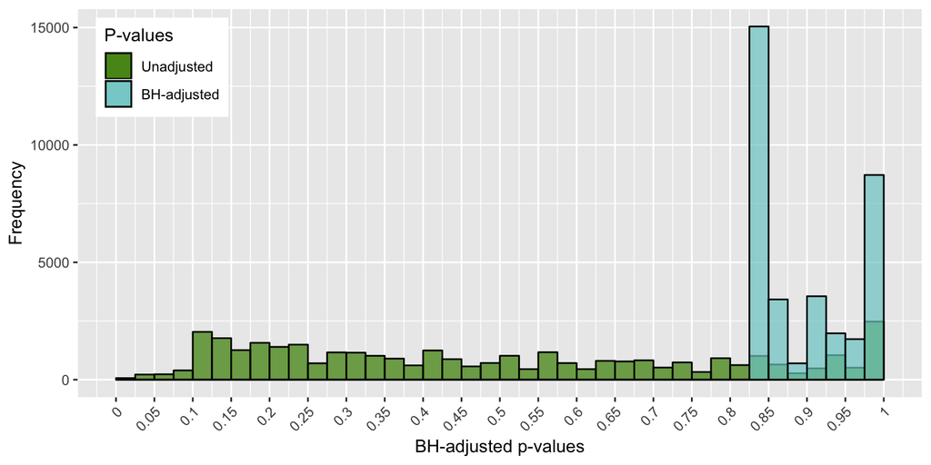

```r
wilcox_tissue_plot <- ggplot(data = crispr_signif_del_tissue) +
  geom_histogram(aes(x = p, fill = "chartreuse4"), breaks = seq(0, 1, by = 0.025), color = "black", alpha = 0.7) +
  geom_histogram(aes(x = p.adj, fill = "darkslategray3"), breaks = seq(0, 1, by = 0.025), color = "black", alpha = 0.7) +
  scale_x_continuous(breaks = seq(0, 1, by = 0.05), labels = seq(0, 1, by = 0.05)) +
  # scale_y_continuous(breaks = seq(0, 50000, by = 5000), labels = formatC(seq(0, 50000, by = 5000), format = "d")) +
  scale_fill_manual(name = "P-values", values = c("chartreuse4" = "chartreuse4", "darkslategray3" = "darkslategray3"), labels = c("Unadjusted", "BH-adjusted")) +
  theme(axis.text.x = element_text(angle = 45, hjust = 1), legend.position = c(0.1, 0.85)) +
  labs(x = "BH-adjusted p-values", y = "Frequency")
wilcox_tissue_plot
```

```r
# ggsave(filename = "./plots_18Q3/crispr/pvals_genes_tissues.pdf", plot = wilcox_tissue_plot, width = 8, height = 4, device = "pdf")
```

### 4.3.2 Non-silent mutant vs. Other

```r
crispr_signif_nonsilent_tissue <- compare_means(Score ~ Mutation_Status_Nonsilent, group.by = c("Hugo_Symbol", "primary_tissue"), data = crispr_data_ptmuts, method = "wilcox.test", p.adjust.method = "BH")
crispr_signif_nonsilent_tissue <- adj_signif(crispr_signif_nonsilent_tissue)
crispr_signif_nonsilent_tissue <- crispr_signif_nonsilent_tissue[order(crispr_signif_nonsilent_tissue$p),]
saveRDS(crispr_signif_nonsilent_tissue, "./data_munging/rds/crispr_signif_nonsilent_tissue.rds")

# write.table(crispr_signif_nonsilent_tissue, file = "~/Desktop/crispr_signif_nonsilent_tissue.csv", quote = FALSE, sep = ",", row.names = FALSE)
```

```r
crispr_signif_nonsilent_tissue <- readRDS("./data_munging/rds/crispr_signif_nonsilent_tissue.rds")

knitr::kable(filter(crispr_signif_nonsilent_tissue, p < 0.05)[, c("Hugo_Symbol", "primary_tissue", "p", "p.adj", "p.format", "p.signif", "p.signif.adj")], caption = "Wilcoxon test results comparing non-silent mutant and other cell lines by tissue, p < 0.05 (BH-adjusted p-values: * p <= 0.05, ** p <= 0.01, *** p <= 0.001, **** p <= 0.0001)") %>% kable_styling(bootstrap_options = c("striped", "hover", "condensed", "responsive")) %>% footnote(general = "Wilcoxon test Benjamini-Hochberg-corrected p-values:\n*: p <= 0.05\n**: p <= 0.01\n***: p <= 0.001\n****: p <= 0.0001") %>% scroll_box(width = "900px", height = "450px")
```

Wilcoxon test results comparing non-silent mutant and other cell lines by tissue, p < 0.05 (BH-adjusted p-values: * p <= 0.05, ** p <= 0.01, *** p <= 0.001, **** p <= 0.0001)

Hugo_Symbol

primary_tissue

p

p.adj

p.format

p.signif

p.signif.adj

SYNE1

lung

0.0140032

1

0.014

NA

BIRC6

lung

0.0207475

1

0.021

NA

PKHD1

lung

0.0255070

1

0.026

NA

KMT2B

breast

0.0265187

1

0.027

NA

KMT2D

ovary

0.0273481

1

0.027

NA

TRPA1

lung

0.0281858

1

0.028

NA

NOS1

lung

0.0292725

1

0.029

NA

TENM4

skin

0.0349263

1

0.035

NA

NEBL

uterus

0.0362034

1

0.036

NA

ABCA8

lung

0.0365463

1

0.037

NA

ADAM11

lung

0.0368884

1

0.037

NA

TJP1

uterus

0.0372492

1

0.037

NA

XYLT2

uterus

0.0372492

1

0.037

NA

LPHN3

lung

0.0375182

1

0.038

NA

RP1L1

lung

0.0379528

1

0.038

NA

SALL4

lung

0.0380559

1

0.038

NA

MMP16

lung

0.0382144

1

0.038

NA

SPATA31D1

lung

0.0385516

1

0.039

NA

SPTBN4

lung

0.0392105

1

0.039

NA

BMPER

lung

0.0396348

1

0.040

NA

POLE

uterus

0.0398748

1

0.040

NA

CMYA5

lung

0.0412580

1

0.041

NA

HCN1

lung

0.0419663

1

0.042

NA

TBC1D9

colorectal

0.0419967

1

0.042

NA

KIAA0100

uterus

0.0420664

1

0.042

NA

CHD5

colorectal

0.0428256

1

0.043

NA

GLI3

colorectal

0.0458662

1

0.046

NA

RRBP1

uterus

0.0491854

1

0.049

NA

ARMC4

uterus

0.0497460

1

0.050

NA

BRINP2

skin

0.0497460

1

0.050

NA

Note:

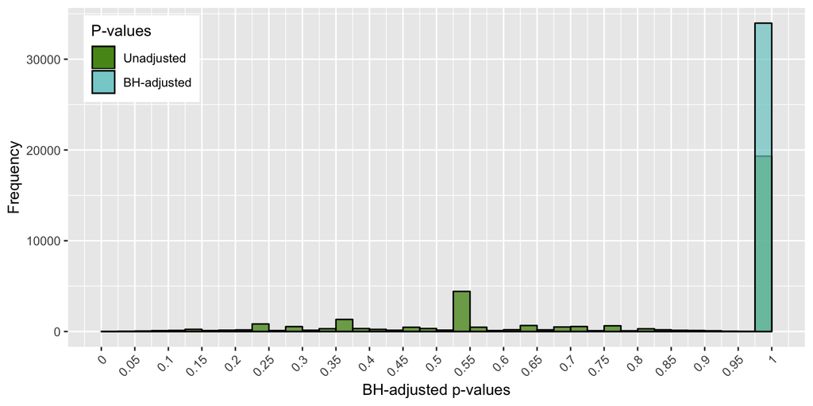

```r
wilcox_tissue_nonsilent_plot <- ggplot(data = crispr_signif_nonsilent_tissue) +
  geom_histogram(aes(x = p, fill = "chartreuse4"), breaks = seq(0, 1, by = 0.025), color = "black", alpha = 0.7) +
  geom_histogram(aes(x = p.adj, fill = "darkslategray3"), breaks = seq(0, 1, by = 0.025), color = "black", alpha = 0.7) +
  scale_x_continuous(breaks = seq(0, 1, by = 0.05), labels = seq(0, 1, by = 0.05)) +
  # coord_cartesian(ylim = c(0, 3500)) +
  # scale_y_continuous(breaks = seq(0, 3500, by = 500), labels = formatC(seq(0, 3500, by = 500), format = "d")) +
  scale_fill_manual(name = "P-values", values = c("chartreuse4" = "chartreuse4", "darkslategray3" = "darkslategray3"), labels = c("Unadjusted", "BH-adjusted")) +
  theme(axis.text.x = element_text(angle = 45, hjust = 1), legend.position = c(0.1, 0.85)) +
  labs(x = "BH-adjusted p-values", y = "Frequency")
wilcox_tissue_nonsilent_plot
```

### 4.3.3 Deleterious and missense mutant vs. Other

```r
crispr_signif_delmis_tissue <- compare_means(Score ~ Mutation_Status_DeleteriousMissense, group.by = c("Hugo_Symbol", "primary_tissue"), data = crispr_data_ptmuts, method = "wilcox.test", p.adjust.method = "BH")
crispr_signif_delmis_tissue <- adj_signif(crispr_signif_delmis_tissue)
crispr_signif_delmis_tissue <- crispr_signif_delmis_tissue[order(crispr_signif_delmis_tissue$p),]
saveRDS(crispr_signif_delmis_tissue, "./data_munging/rds/crispr_signif_deleteriousmissense_tissue.rds")

# write.table(crispr_signif_delmis_tissue, file = "~/Desktop/crispr_signif_deleteriousmissense_tissue.csv", quote = FALSE, sep = ",", row.names = FALSE)
```

```r
crispr_signif_delmis_tissue <- readRDS("./data_munging/rds/crispr_signif_deleteriousmissense_tissue.rds")

knitr::kable(filter(crispr_signif_delmis_tissue, p < 0.05)[, c("Hugo_Symbol", "primary_tissue", "p", "p.adj", "p.format", "p.signif", "p.signif.adj")], caption = "Wilcoxon test results comparing deleterious and missense mutant and other cell lines by tissue, p < 0.05 (BH-adjusted p-values: * p <= 0.05, ** p <= 0.01, *** p <= 0.001, **** p <= 0.0001)") %>% kable_styling(bootstrap_options = c("striped", "hover", "condensed", "responsive")) %>% footnote(general = "Wilcoxon test Benjamini-Hochberg-corrected p-values:\n*: p <= 0.05\n**: p <= 0.01\n***: p <= 0.001\n****: p <= 0.0001") %>% scroll_box(width = "900px", height = "450px")
```

Wilcoxon test results comparing deleterious and missense mutant and other cell lines by tissue, p < 0.05 (BH-adjusted p-values: * p <= 0.05, ** p <= 0.01, *** p <= 0.001, **** p <= 0.0001)

Hugo_Symbol

primary_tissue

p

p.adj

p.format

p.signif

p.signif.adj

SYNE1

lung

0.0140032

1

0.014

NA

BIRC6

lung

0.0207475

1

0.021

NA

PKHD1

lung

0.0255070

1

0.026

NA

KMT2B

breast

0.0265187

1

0.027

NA

KMT2D

ovary

0.0273481

1

0.027

NA

TRPA1

lung

0.0281858

1

0.028

NA

NOS1

lung

0.0292725

1

0.029

NA

TENM4

skin

0.0349263

1

0.035

NA

NEBL

uterus

0.0362034

1

0.036

NA

ABCA8

lung

0.0365463

1

0.037

NA

ADAM11

lung

0.0368884

1

0.037

NA

TJP1

uterus

0.0372492

1

0.037

NA

XYLT2

uterus

0.0372492

1

0.037

NA

LPHN3

lung

0.0375182

1

0.038

NA

RP1L1

lung

0.0379528

1

0.038

NA

SALL4

lung

0.0380559

1

0.038

NA

MMP16

lung

0.0382144

1

0.038

NA

SPATA31D1

lung

0.0385516

1

0.039

NA

SPTBN4

lung

0.0392105

1

0.039

NA

BMPER

lung

0.0396348

1

0.040

NA

POLE

uterus

0.0398748

1

0.040

NA

CMYA5

lung

0.0412580

1

0.041

NA

HCN1

lung

0.0419663

1

0.042

NA

TBC1D9

colorectal

0.0419967

1

0.042

NA

KIAA0100

uterus

0.0420664

1

0.042

NA

CHD5

colorectal

0.0428256

1

0.043

NA

GLI3

colorectal

0.0458662

1

0.046

NA

RRBP1

uterus

0.0491854

1

0.049

NA

ARMC4

uterus

0.0497460

1

0.050

NA

BRINP2

skin

0.0497460

1

0.050

NA

Note:

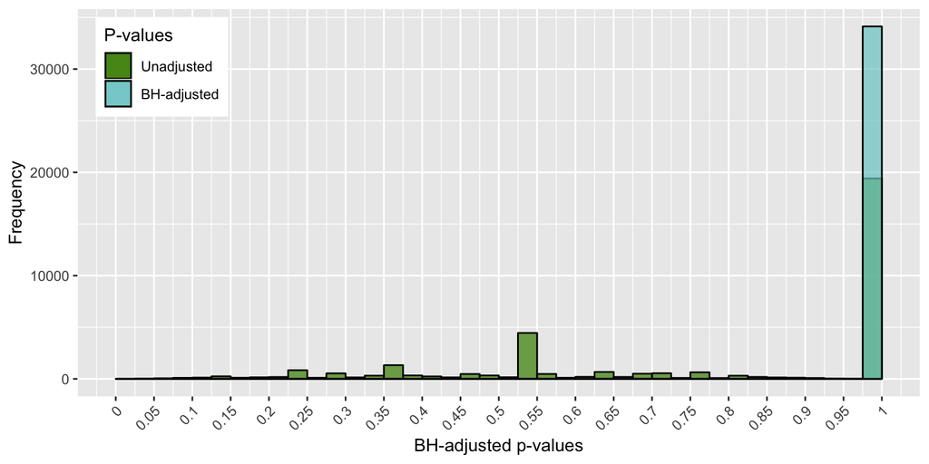

```r
wilcox_gene_delmis_tissue_plot <- ggplot(data = crispr_signif_delmis_tissue) +
  geom_histogram(aes(x = p, fill = "chartreuse4"), breaks = seq(0, 1, by = 0.025), color = "black", alpha = 0.7) +
  geom_histogram(aes(x = p.adj, fill = "darkslategray3"), breaks = seq(0, 1, by = 0.025), color = "black", alpha = 0.7) +
  scale_x_continuous(breaks = seq(0, 1, by = 0.05), labels = seq(0, 1, by = 0.05)) +
  # coord_cartesian(ylim = c(0, 3500)) +
  # scale_y_continuous(breaks = seq(0, 3500, by = 500), labels = formatC(seq(0, 3500, by = 500), format = "d")) +
  scale_fill_manual(name = "P-values", values = c("chartreuse4" = "chartreuse4", "darkslategray3" = "darkslategray3"), labels = c("Unadjusted", "BH-adjusted")) +
  theme(axis.text.x = element_text(angle = 45, hjust = 1), legend.position = c(0.1, 0.85)) +
  labs(x = "BH-adjusted p-values", y = "Frequency")
wilcox_gene_delmis_tissue_plot
```

# 5 Heatmaps

## 5.1 Data management

The mutation status portion of these heatmaps was made using deleterious and missense mutations as “mutant” and all others as “other.”

Make and save heatmap data matrices:

```r
# Set up heatmap data
chm_scores <- t(crispr)
colnames(chm_scores) <- chm_scores[1, ]
chm_scores <- chm_scores[-1, ]
chm_rows <- rownames(chm_scores)
chm_cols <- colnames(chm_scores)
chm_scores <- apply(chm_scores, 2, as.double)
chm_scores <- apply(chm_scores, 2, function(x) (x - mean(x)) / var(x))
colnames(chm_scores) <- chm_cols
rownames(chm_scores) <- chm_rows
saveRDS(chm_scores, "./data_munging/rds/crispr_heatmap_scores.rds")

# Make full grid for genomic features
crispr_grid_ccls <- unique(crispr_data$Broad_ID)
crispr_grid_genes <- unique(crispr_data$Hugo_Symbol)
crispr_grid <- expand.grid("Broad_ID" = crispr_grid_ccls, "Hugo_Symbol" = crispr_grid_genes)

# Gene expression
ge_filt <- filter(ge_melt, Hugo_Symbol %in% unique(crispr_data$Hugo_Symbol))[, c("Hugo_Symbol", "Broad_ID", "RPKM")]
ge_filt$RPKM <- log2(ge_filt$RPKM + 0.0001)
chm_ge_grid <- merge(crispr_grid, ge_filt, by = c("Broad_ID", "Hugo_Symbol"), all.x = TRUE)
chm_ge <- reshape(chm_ge_grid, idvar = "Hugo_Symbol", timevar = "Broad_ID", direction = "wide")
chm_ge_rows <- chm_ge$Hugo_Symbol
chm_ge$Hugo_Symbol <- NULL
chm_ge_cols <- colnames(chm_ge) %>% gsub("RPKM.", "", .)
chm_ge <- apply(chm_ge, 2, as.double)
chm_ge <- apply(chm_ge, 2, function(x) (x - mean(x, na.rm = TRUE)) / var(x, na.rm = TRUE))
rownames(chm_ge) <- chm_ge_rows
colnames(chm_ge) <- chm_ge_cols
saveRDS(chm_ge, "./data_munging/rds/crispr_heatmap_ge.rds")

# Mutation status
chm_mut_grid <- merge(crispr_grid, maf_df[, c("Broad_ID", "Hugo_Symbol", "Mutation_Status")], by = c("Broad_ID", "Hugo_Symbol"), all.x = TRUE)
chm_mut_grid$Mutation_Status <- ifelse(is.na(chm_mut_grid$Mutation_Status), "Other", chm_mut_grid$Mutation_Status)
chm_mut_grid$Mutation_Status <- ifelse(chm_mut_grid$Mutation_Status == "Other", 0, 1)
chm_mut <- reshape(chm_mut_grid, idvar = "Hugo_Symbol", timevar = "Broad_ID", direction = "wide")
chm_mut_rows <- chm_mut$Hugo_Symbol
chm_mut$Hugo_Symbol <- NULL
chm_mut_cols <- colnames(chm_mut) %>% gsub("Mutation_Status.", "", .)
chm_mut <- matrix(as.numeric(unlist(chm_mut)), nrow = nrow(chm_mut))
rownames(chm_mut) <- chm_mut_rows
colnames(chm_mut) <- chm_mut_cols
saveRDS(chm_mut, "./data_munging/rds/crispr_heatmap_mut.rds")

# Copy number
cn_filt <- filter(cn_melt, Hugo_Symbol %in% unique(crispr_data$Hugo_Symbol))
chm_cn_grid <- merge(crispr_grid, cn_melt, by = c("Broad_ID", "Hugo_Symbol"), all.x = TRUE)
chm_cn <- reshape(chm_cn_grid, idvar = "Hugo_Symbol", timevar = "Broad_ID", direction = "wide")
chm_cn_rows <- chm_cn$Hugo_Symbol
chm_cn$Hugo_Symbol <- NULL
chm_cn_cols <- colnames(chm_cn) %>% gsub("Copy_Number.", "", .)
chm_cn <- apply(chm_cn, 2, as.double)
chm_cn <- apply(chm_cn, 2, function(x) (x - mean(x, na.rm = TRUE)) / var(x, na.rm = TRUE))
rownames(chm_cn) <- chm_cn_rows
colnames(chm_cn) <- chm_cn_cols
saveRDS(chm_cn, "./data_munging/rds/crispr_heatmap_cn.rds")
```

Load heatmap matrices:

```r
chm_scores <- readRDS("./data_munging/rds/crispr_heatmap_scores.rds")
chm_ge <- readRDS("./data_munging/rds/crispr_heatmap_ge.rds")
chm_mut <- readRDS("./data_munging/rds/crispr_heatmap_mut.rds")
chm_cn <- readRDS("./data_munging/rds/crispr_heatmap_cn.rds")

# Metadata anotation dataframe
chm_annot <- merge(merge(data.frame("Broad_ID" = crispr$Broad_ID), crispr_meta[, c("Broad_ID", "cell_line_SSMD", "cas9_activity", "culture_type", "primary_tissue")], by = "Broad_ID", all.x = TRUE), ccl_info[, c("Broad_ID", "Primary.Disease", "Gender", "Source")], by = "Broad_ID", all.x = TRUE)
rownames(chm_annot) <- chm_annot$Broad_ID
chm_annot$Broad_ID <- NULL
colnames(chm_annot) <- c("Cell_Line_SSMD", "Cas9_Activity", "Culture_Type", "Primary_Tissue", "Primary_Disease", "Gender", "Source")
chm_annot$Cell_Line_SSMD <- as.numeric(chm_annot$Cell_Line_SSMD)
chm_annot$Cas9_Activity <- as.numeric(chm_annot$Cas9_Activity)
```

## 5.2 All genes, no omics

```r
chm_annot_list <- HeatmapAnnotation(df = chm_annot, annotation_legend_param = list(
  Cell_Line_SSMD = list(title = "Cell Line SSMD", title_gp = gpar(fontsize = 20), labels_gp = gpar(fontsize = 15), title_position = "topcenter", legend_height = unit(2, "in")),
  Cas9_Activity = list(title = "Cas9 Activity", title_gp = gpar(fontsize = 20), labels_gp = gpar(fontsize = 15), title_position = "topcenter", legend_height = unit(2, "in")),
  Culture_Type = list(title = "Culture Type", title_gp = gpar(fontsize = 20), labels_gp = gpar(fontsize = 15), nrow = 8, title = "Culture Type", title_position = "topleft", grid_height = unit(0.3, "in")),
  Primary_Tissue = list(title = "Primary Tissue", title_gp = gpar(fontsize = 20), labels_gp = gpar(fontsize = 15), nrow = 8, title = "Primary_Tissue", title_position = "topleft", grid_height = unit(0.3, "in")),
  Primary_Disease = list(title = "Primary Disease", title_gp = gpar(fontsize = 20), labels_gp = gpar(fontsize = 15), nrow = 8, title = "Primary Disease", title_position = "topleft", grid_height = unit(0.3, "in")),
  Gender = list(title_gp = gpar(fontsize = 20), labels_gp = gpar(fontsize = 15), grid_height = unit(0.3, "in")),
  Source = list(title_gp = gpar(fontsize = 20), labels_gp = gpar(fontsize = 15), nrow = 8, title = "Source", title_position = "topleft", grid_height = unit(0.3, "in"))))

chm_all_plot <- Heatmap(chm_scores, name = "CERES Score",
        bottom_annotation = chm_annot_list,
        bottom_annotation_height = unit(5, "in"),
        heatmap_legend_param = list(title_gp = gpar(fontsize = 20), labels_gp = gpar(fontsize = 15), title_position = "topcenter", legend_height = unit(2, "in")),
        row_title = "Genes", column_title = "Cancer Cell Lines",
        col = colorRamp2(c(min(chm_scores), 0, max(chm_scores)), c("purple4", "white", "seagreen4")),
        na_col = "black",
        row_title_gp = gpar(fontsize = 30, fontface = "bold"),
        row_names_gp = gpar(fontsize = 5),
        column_title_gp = gpar(fontsize = 30, fontface = "bold"),
        column_names_gp = gpar(fontsize = 5),
        row_dend_reorder = TRUE,
        column_dend_reorder = TRUE,
        clustering_distance_rows = "euclidean",
        clustering_distance_columns = "euclidean",
        clustering_method_rows = "complete",
        clustering_method_columns = "complete",
        column_dend_height = unit(2, "in"),
        row_dend_width = unit(4, "in"),
        width = 3)

pdf("./plots_18Q3/crispr_heatmap_euclidean_all.pdf", width = 50, height = 50, paper = "special")
draw(chm_all_plot, heatmap_legend_side = "bottom", annotation_legend_side = "bottom")
seekViewport("annotation_Cell_Line_SSMD")
grid.text("Cell Line SSMD", unit(1, "npc") + unit(1, "mm"), 0.5, gp = gpar(fontsize = 15), default.units = "npc", just = "left")
seekViewport("annotation_Cas9_Activity")
grid.text("Cas9 Activity", unit(1, "npc") + unit(1, "mm"), 0.5, gp = gpar(fontsize = 15), default.units = "npc", just = "left")
seekViewport("annotation_Culture_Type")
grid.text("Culture Type", unit(1, "npc") + unit(1, "mm"), 0.5, gp = gpar(fontsize = 15), default.units = "npc", just = "left")
seekViewport("annotation_Primary_Tissue")
grid.text("Primary Tissue", unit(1, "npc") + unit(1, "mm"), 0.5, gp = gpar(fontsize = 15), default.units = "npc", just = "left")
seekViewport("annotation_Primary_Disease")
grid.text("Primary Disease", unit(1, "npc") + unit(1, "mm"), 0.5, gp = gpar(fontsize = 15), default.units = "npc", just = "left")
seekViewport("annotation_Gender")
grid.text("Gender", unit(1, "npc") + unit(1, "mm"), 0.5, gp = gpar(fontsize = 15), default.units = "npc", just = "left")
seekViewport("annotation_Source")
grid.text("Source", unit(1, "npc") + unit(1, "mm"), 0.5, gp = gpar(fontsize = 15), default.units = "npc", just = "left")
dev.off()

png("./plots_18Q3/crispr_heatmap_euclidean_all.png", width = 50, height = 50, units = "in", res = 96)
draw(chm_all_plot, heatmap_legend_side = "bottom", annotation_legend_side = "bottom")
seekViewport("annotation_Cell_Line_SSMD")
grid.text("Cell Line SSMD", unit(1, "npc") + unit(1, "mm"), 0.5, gp = gpar(fontsize = 15), default.units = "npc", just = "left")
seekViewport("annotation_Cas9_Activity")
grid.text("Cas9 Activity", unit(1, "npc") + unit(1, "mm"), 0.5, gp = gpar(fontsize = 15), default.units = "npc", just = "left")
seekViewport("annotation_Culture_Type")
grid.text("Culture Type", unit(1, "npc") + unit(1, "mm"), 0.5, gp = gpar(fontsize = 15), default.units = "npc", just = "left")
seekViewport("annotation_Primary_Tissue")
grid.text("Primary Tissue", unit(1, "npc") + unit(1, "mm"), 0.5, gp = gpar(fontsize = 15), default.units = "npc", just = "left")
seekViewport("annotation_Primary_Disease")
grid.text("Primary Disease", unit(1, "npc") + unit(1, "mm"), 0.5, gp = gpar(fontsize = 15), default.units = "npc", just = "left")
seekViewport("annotation_Gender")
grid.text("Gender", unit(1, "npc") + unit(1, "mm"), 0.5, gp = gpar(fontsize = 15), default.units = "npc", just = "left")
seekViewport("annotation_Source")
grid.text("Source", unit(1, "npc") + unit(1, "mm"), 0.5, gp = gpar(fontsize = 15), default.units = "npc", just = "left")
dev.off()
```

## 5.3 CGC genes

Code for heatmap of CGC-filtered genes only

### 5.3.1 Euclidean distance

```r
chm_scores_cgc <- subset(chm_scores, rownames(chm_scores) %in% cgc$Hugo_Symbol)
chm_ge_cgc <- subset(chm_ge, rownames(chm_ge) %in% cgc$Hugo_Symbol)
chm_mut_cgc <- subset(chm_mut, rownames(chm_mut) %in% cgc$Hugo_Symbol)
chm_cn_cgc <- subset(chm_cn, rownames(chm_cn) %in% cgc$Hugo_Symbol)

chm_annot_list <- HeatmapAnnotation(df = chm_annot, annotation_legend_param = list(
  Cell_Line_SSMD = list(title = "Cell Line SSMD", title_gp = gpar(fontsize = 20), labels_gp = gpar(fontsize = 15), title_position = "topcenter", legend_height = unit(2, "in")),
  Cas9_Activity = list(title = "Cas9 Activity", title_gp = gpar(fontsize = 20), labels_gp = gpar(fontsize = 15), title_position = "topcenter", legend_height = unit(2, "in")),
  Culture_Type = list(title = "Culture Type", title_gp = gpar(fontsize = 20), labels_gp = gpar(fontsize = 15), nrow = 8, title = "Culture Type", title_position = "topleft", grid_height = unit(0.3, "in")),
  Primary_Tissue = list(title = "Primary Tissue", title_gp = gpar(fontsize = 20), labels_gp = gpar(fontsize = 15), nrow = 8, title = "Primary_Tissue", title_position = "topleft", grid_height = unit(0.3, "in")),
  Primary_Disease = list(title = "Primary Disease", title_gp = gpar(fontsize = 20), labels_gp = gpar(fontsize = 15), nrow = 8, title = "Primary Disease", title_position = "topleft", grid_height = unit(0.3, "in")),
  Gender = list(title_gp = gpar(fontsize = 20), labels_gp = gpar(fontsize = 15), grid_height = unit(0.3, "in")),
  Source = list(title_gp = gpar(fontsize = 20), labels_gp = gpar(fontsize = 15), nrow = 8, title = "Source", title_position = "topleft", grid_height = unit(0.3, "in"))))

chm_plot_cgc <- Heatmap(chm_scores_cgc, name = "CERES Score",
        bottom_annotation = chm_annot_list,
        bottom_annotation_height = unit(5, "in"),
        heatmap_legend_param = list(title_gp = gpar(fontsize = 20), labels_gp = gpar(fontsize = 15), title_position = "topcenter", legend_height = unit(2, "in")),
        row_title = "Genes", column_title = "Cancer Cell Lines",
        col = colorRamp2(c(min(chm_scores_cgc), 0, max(chm_scores_cgc)), c("purple4", "white", "seagreen4")),
        na_col = "black",
        row_title_gp = gpar(fontsize = 30, fontface = "bold"),
        row_names_gp = gpar(fontsize = 5),
        column_title_gp = gpar(fontsize = 30, fontface = "bold"),
        column_names_gp = gpar(fontsize = 5),
        row_dend_reorder = TRUE,
        column_dend_reorder = TRUE,
        clustering_distance_rows = "euclidean",
        clustering_distance_columns = "euclidean",
        clustering_method_rows = "complete",
        clustering_method_columns = "complete",
        column_dend_height = unit(2, "in"),
        row_dend_width = unit(4, "in"),
        width = 3)

chm_plot_cgc_cols <- colnames(chm_scores_cgc)[unlist(column_order(chm_plot_cgc))]
chm_plot_cgc_rows <- rownames(chm_scores_cgc)[unlist(row_order(chm_plot_cgc))]

chm_ge_plot_cgc <- Heatmap(chm_ge_cgc, name = "Gene Expression",
        col = colorRamp2(c(min(chm_ge_cgc[!is.na(chm_ge_cgc)]), 0, max(chm_ge_cgc[!is.na(chm_ge_cgc)])), c("dodgerblue4", "white", "firebrick4")),
        heatmap_legend_param = list(title_gp = gpar(fontsize = 20), labels_gp = gpar(fontsize = 15), title_position = "topcenter", legend_height = unit(2, "in")),
        na_col = "black",
        cluster_rows = FALSE, cluster_columns = FALSE,
        row_names_gp = gpar(fontsize = 5), show_column_names = FALSE,
        column_title = "Gene Expression",
        column_title_gp = gpar(fontsize = 30, fontface = "bold"),
        column_order = chm_plot_cgc_cols,
        row_order = chm_plot_cgc_rows,
        width = 1)
chm_cn_plot_cgc <- Heatmap(chm_cn_cgc, name = "Copy Number",
        col = colorRamp2(c(min(chm_cn_cgc[!is.na(chm_cn_cgc)]), 0, max(chm_cn_cgc[!is.na(chm_cn_cgc)])), c("white", "thistle2", "mediumorchid4")),
        heatmap_legend_param = list(title_gp = gpar(fontsize = 20), labels_gp = gpar(fontsize = 15), title_position = "topcenter", legend_height = unit(2, "in")),
        na_col = "black",
        cluster_rows = FALSE, cluster_columns = FALSE,
        row_names_gp = gpar(fontsize = 5), show_column_names = FALSE,
        column_title = "Copy Number",
        column_title_gp = gpar(fontsize = 30, fontface = "bold"),
        column_order = chm_plot_cgc_cols,
        row_order = chm_plot_cgc_rows,
        width = 1)
chm_mut_plot_cgc <- Heatmap(chm_mut_cgc, name = "Mutation Status",
        na_col = "black",
        heatmap_legend_param = list(title_gp = gpar(fontsize = 20), labels_gp = gpar(fontsize = 15), at = c(0, 1), labels = c("Other", "Mutant"), title_position = "topcenter", grid_height = unit(0.3, "in")),
        col = c("cyan3", "darkorchid"),
        cluster_rows = FALSE, cluster_columns = FALSE,
        row_names_gp = gpar(fontsize = 5), show_column_names = FALSE,
        column_title = "Mutation Status",
        column_title_gp = gpar(fontsize = 30, fontface = "bold"),
        column_order = chm_plot_cgc_cols,
        row_order = chm_plot_cgc_rows,
        width = 1)

chm_all_plot_cgc <- chm_plot_cgc + chm_ge_plot_cgc + chm_cn_plot_cgc + chm_mut_plot_cgc

pdf("./plots_18Q3/crispr_heatmap_euclidean_all_cgc.pdf", width = 50, height = 50, paper = "special")
draw(chm_all_plot_cgc, heatmap_legend_side = "bottom", annotation_legend_side = "bottom")
seekViewport("annotation_Cell_Line_SSMD")
grid.text("Cell Line SSMD", unit(1, "npc") + unit(1, "mm"), 0.5, gp = gpar(fontsize = 15), default.units = "npc", just = "left")
seekViewport("annotation_Cas9_Activity")
grid.text("Cas9 Activity", unit(1, "npc") + unit(1, "mm"), 0.5, gp = gpar(fontsize = 15), default.units = "npc", just = "left")
seekViewport("annotation_Culture_Type")
grid.text("Culture Type", unit(1, "npc") + unit(1, "mm"), 0.5, gp = gpar(fontsize = 15), default.units = "npc", just = "left")
seekViewport("annotation_Primary_Tissue")
grid.text("Primary Tissue", unit(1, "npc") + unit(1, "mm"), 0.5, gp = gpar(fontsize = 15), default.units = "npc", just = "left")
seekViewport("annotation_Primary_Disease")
grid.text("Primary Disease", unit(1, "npc") + unit(1, "mm"), 0.5, gp = gpar(fontsize = 15), default.units = "npc", just = "left")
seekViewport("annotation_Gender")
grid.text("Gender", unit(1, "npc") + unit(1, "mm"), 0.5, gp = gpar(fontsize = 15), default.units = "npc", just = "left")
seekViewport("annotation_Source")
grid.text("Source", unit(1, "npc") + unit(1, "mm"), 0.5, gp = gpar(fontsize = 15), default.units = "npc", just = "left")
dev.off()

png("./plots_18Q3/crispr_heatmap_euclidean_all_cgc.png", width = 50, height = 50, units = "in", res = 96)
draw(chm_all_plot_cgc, heatmap_legend_side = "bottom", annotation_legend_side = "bottom")
seekViewport("annotation_Cell_Line_SSMD")
grid.text("Cell Line SSMD", unit(1, "npc") + unit(1, "mm"), 0.5, gp = gpar(fontsize = 15), default.units = "npc", just = "left")
seekViewport("annotation_Cas9_Activity")
grid.text("Cas9 Activity", unit(1, "npc") + unit(1, "mm"), 0.5, gp = gpar(fontsize = 15), default.units = "npc", just = "left")
seekViewport("annotation_Culture_Type")
grid.text("Culture Type", unit(1, "npc") + unit(1, "mm"), 0.5, gp = gpar(fontsize = 15), default.units = "npc", just = "left")
seekViewport("annotation_Primary_Tissue")
grid.text("Primary Tissue", unit(1, "npc") + unit(1, "mm"), 0.5, gp = gpar(fontsize = 15), default.units = "npc", just = "left")
seekViewport("annotation_Primary_Disease")
grid.text("Primary Disease", unit(1, "npc") + unit(1, "mm"), 0.5, gp = gpar(fontsize = 15), default.units = "npc", just = "left")
seekViewport("annotation_Gender")
grid.text("Gender", unit(1, "npc") + unit(1, "mm"), 0.5, gp = gpar(fontsize = 15), default.units = "npc", just = "left")
seekViewport("annotation_Source")
grid.text("Source", unit(1, "npc") + unit(1, "mm"), 0.5, gp = gpar(fontsize = 15), default.units = "npc", just = "left")
dev.off()
```

### 5.3.2 Pearson correlation

```r
chm_scores_cgc <- subset(chm_scores, rownames(chm_scores) %in% cgc$Hugo_Symbol)
chm_ge_cgc <- subset(chm_ge, rownames(chm_ge) %in% cgc$Hugo_Symbol)
chm_mut_cgc <- subset(chm_mut, rownames(chm_mut) %in% cgc$Hugo_Symbol)
chm_cn_cgc <- subset(chm_cn, rownames(chm_cn) %in% cgc$Hugo_Symbol)

chm_annot_list <- HeatmapAnnotation(df = chm_annot, annotation_legend_param = list(
  Cell_Line_SSMD = list(title = "Cell Line SSMD", title_gp = gpar(fontsize = 20), labels_gp = gpar(fontsize = 15), title_position = "topcenter", legend_height = unit(2, "in")),
  Cas9_Activity = list(title = "Cas9 Activity", title_gp = gpar(fontsize = 20), labels_gp = gpar(fontsize = 15), title_position = "topcenter", legend_height = unit(2, "in")),
  Culture_Type = list(title = "Culture Type", title_gp = gpar(fontsize = 20), labels_gp = gpar(fontsize = 15), nrow = 8, title = "Culture Type", title_position = "topleft", grid_height = unit(0.3, "in")),
  Primary_Tissue = list(title = "Primary Tissue", title_gp = gpar(fontsize = 20), labels_gp = gpar(fontsize = 15), nrow = 8, title = "Primary_Tissue", title_position = "topleft", grid_height = unit(0.3, "in")),
  Primary_Disease = list(title = "Primary Disease", title_gp = gpar(fontsize = 20), labels_gp = gpar(fontsize = 15), nrow = 8, title = "Primary Disease", title_position = "topleft", grid_height = unit(0.3, "in")),
  Gender = list(title_gp = gpar(fontsize = 20), labels_gp = gpar(fontsize = 15), grid_height = unit(0.3, "in")),
  Source = list(title_gp = gpar(fontsize = 20), labels_gp = gpar(fontsize = 15), nrow = 8, title = "Source", title_position = "topleft", grid_height = unit(0.3, "in"))))

chm_plot_cgc <- Heatmap(chm_scores_cgc, name = "CERES Score",
        bottom_annotation = chm_annot_list,
        bottom_annotation_height = unit(5, "in"),
        heatmap_legend_param = list(title_gp = gpar(fontsize = 20), labels_gp = gpar(fontsize = 15), title_position = "topcenter", legend_height = unit(2, "in")),
        row_title = "Genes", column_title = "Cancer Cell Lines",
        col = colorRamp2(c(min(chm_scores_cgc), 0, max(chm_scores_cgc)), c("purple4", "white", "seagreen4")),
        na_col = "black",
        row_title_gp = gpar(fontsize = 30, fontface = "bold"),
        row_names_gp = gpar(fontsize = 5),
        column_title_gp = gpar(fontsize = 30, fontface = "bold"),
        column_names_gp = gpar(fontsize = 5),
        row_dend_reorder = TRUE,
        column_dend_reorder = TRUE,
        clustering_distance_rows = "pearson",
        clustering_distance_columns = "pearson",
        clustering_method_rows = "complete",
        clustering_method_columns = "complete",
        column_dend_height = unit(2, "in"),
        row_dend_width = unit(4, "in"),
        width = 3)

chm_plot_cgc_cols <- colnames(chm_scores_cgc)[unlist(column_order(chm_plot_cgc))]
chm_plot_cgc_rows <- rownames(chm_scores_cgc)[unlist(row_order(chm_plot_cgc))]

chm_ge_plot_cgc <- Heatmap(chm_ge_cgc, name = "Gene Expression",
        col = colorRamp2(c(min(chm_ge_cgc[!is.na(chm_ge_cgc)]), 0, max(chm_ge_cgc[!is.na(chm_ge_cgc)])), c("dodgerblue4", "white", "firebrick4")),
        heatmap_legend_param = list(title_gp = gpar(fontsize = 20), labels_gp = gpar(fontsize = 15), title_position = "topcenter", legend_height = unit(2, "in")),
        na_col = "black",
        cluster_rows = FALSE, cluster_columns = FALSE,
        row_names_gp = gpar(fontsize = 5), show_column_names = FALSE,
        column_title = "Gene Expression",
        column_title_gp = gpar(fontsize = 30, fontface = "bold"),
        column_order = chm_plot_cgc_cols,
        row_order = chm_plot_cgc_rows,
        width = 1)
chm_cn_plot_cgc <- Heatmap(chm_cn_cgc, name = "Copy Number",
        col = colorRamp2(c(min(chm_cn_cgc[!is.na(chm_cn_cgc)]), 0, max(chm_cn_cgc[!is.na(chm_cn_cgc)])), c("white", "thistle2", "mediumorchid4")),
        heatmap_legend_param = list(title_gp = gpar(fontsize = 20), labels_gp = gpar(fontsize = 15), title_position = "topcenter", legend_height = unit(2, "in")),
        na_col = "black",
        cluster_rows = FALSE, cluster_columns = FALSE,
        row_names_gp = gpar(fontsize = 5), show_column_names = FALSE,
        column_title = "Copy Number",
        column_title_gp = gpar(fontsize = 30, fontface = "bold"),
        column_order = chm_plot_cgc_cols,
        row_order = chm_plot_cgc_rows,
        width = 1)
chm_mut_plot_cgc <- Heatmap(chm_mut_cgc, name = "Mutation Status",
        na_col = "black",
        heatmap_legend_param = list(title_gp = gpar(fontsize = 20), labels_gp = gpar(fontsize = 15), at = c(0, 1), labels = c("Other", "Mutant"), title_position = "topcenter", grid_height = unit(0.3, "in")),
        col = c("cyan3", "darkorchid"),
        cluster_rows = FALSE, cluster_columns = FALSE,
        row_names_gp = gpar(fontsize = 5), show_column_names = FALSE,
        column_title = "Mutation Status",
        column_title_gp = gpar(fontsize = 30, fontface = "bold"),
        column_order = chm_plot_cgc_cols,
        row_order = chm_plot_cgc_rows,
        width = 1)

chm_all_plot_cgc <- chm_plot_cgc + chm_ge_plot_cgc + chm_cn_plot_cgc + chm_mut_plot_cgc

pdf("./plots_18Q3/crispr_heatmap_pearson_all_cgc.pdf", width = 50, height = 50, paper = "special")
draw(chm_all_plot_cgc, heatmap_legend_side = "bottom", annotation_legend_side = "bottom")
seekViewport("annotation_Cell_Line_SSMD")
grid.text("Cell Line SSMD", unit(1, "npc") + unit(1, "mm"), 0.5, gp = gpar(fontsize = 15), default.units = "npc", just = "left")
seekViewport("annotation_Cas9_Activity")
grid.text("Cas9 Activity", unit(1, "npc") + unit(1, "mm"), 0.5, gp = gpar(fontsize = 15), default.units = "npc", just = "left")
seekViewport("annotation_Culture_Type")
grid.text("Culture Type", unit(1, "npc") + unit(1, "mm"), 0.5, gp = gpar(fontsize = 15), default.units = "npc", just = "left")
seekViewport("annotation_Primary_Tissue")
grid.text("Primary Tissue", unit(1, "npc") + unit(1, "mm"), 0.5, gp = gpar(fontsize = 15), default.units = "npc", just = "left")
seekViewport("annotation_Primary_Disease")
grid.text("Primary Disease", unit(1, "npc") + unit(1, "mm"), 0.5, gp = gpar(fontsize = 15), default.units = "npc", just = "left")
seekViewport("annotation_Gender")
grid.text("Gender", unit(1, "npc") + unit(1, "mm"), 0.5, gp = gpar(fontsize = 15), default.units = "npc", just = "left")
seekViewport("annotation_Source")
grid.text("Source", unit(1, "npc") + unit(1, "mm"), 0.5, gp = gpar(fontsize = 15), default.units = "npc", just = "left")
dev.off()
```

# 6 Per-gene plots

## 6.1 Grouped plots

Plot code:

```r
crispr_data_cgc <- filter(crispr_data, Hugo_Symbol %in% cgc$Hugo_Symbol)
crispr_all_genes <- unique(crispr_data_cgc$Hugo_Symbol)
crispr_all_groups <- lapply(crispr_all_genes, makeCRISPRgrob)
crispr_all_groups_paths <- paste0(crispr_all_genes, "_crispr_grouped.png")
pwalk(list(crispr_all_groups_paths, crispr_all_groups), ggsave, path = "./plots_18Q3/crispr_grouped_plots_cgc", dpi = 300, width = 12, height = 12, units = "in")
```

Data management:

```r
crispr_all_bygene <- paste0(list.files("./plots_18Q3/crispr_grouped_plots_cgc", full.names = TRUE))
names(crispr_all_bygene) <- str_replace_all(crispr_all_bygene, c("_crispr_grouped.png" = "", "./plots_18Q3/crispr_grouped_plots_cgc/" = ""))
crispr_bygene_order <- c(intersect(crispr_signif$Hugo_Symbol, names(crispr_all_bygene)), setdiff(names(crispr_all_bygene), crispr_signif$Hugo_Symbol))
crispr_all_bygene <- crispr_all_bygene[match(crispr_bygene_order, names(crispr_all_bygene))]
bsselect(crispr_all_bygene, type = "img", selected = "KRAS", live_search = TRUE, show_tick = TRUE, height = 300, frame_height = 275)
```

## 6.2 Sorted lineage plots

Plot code:

```r
crispr_data_cgc <- filter(crispr_data, Hugo_Symbol %in% cgc$Hugo_Symbol)
crispr_all_genes <- unique(crispr_data_cgc$Hugo_Symbol)
crispr_all_lins <- lapply(crispr_all_genes, makeCRISPRlinplot)
crispr_all_lins_paths <- paste0(crispr_all_genes, "_crispr_lineage.png")
pwalk(list(crispr_all_lins_paths, crispr_all_lins), ggsave, path = "./plots_18Q3/crispr_lineage_plots_cgc", dpi = 300, width = 12, height = 12, units = "in")
```

Data management:

```r
crispr_all_bygene <- paste0(list.files("./plots_18Q3/crispr_lineage_plots_cgc", full.names = TRUE))
names(crispr_all_bygene) <- str_replace_all(crispr_all_bygene, c("_crispr_lineage.png" = "", "./plots_18Q3/crispr_lineage_plots_cgc/" = ""))
crispr_bygene_order <- c(intersect(crispr_signif$Hugo_Symbol, names(crispr_all_bygene)), setdiff(names(crispr_all_bygene), crispr_signif$Hugo_Symbol))
crispr_all_bygene <- crispr_all_bygene[match(crispr_bygene_order, names(crispr_all_bygene))]
bsselect(crispr_all_bygene, type = "img", selected = "KRAS", live_search = TRUE, show_tick = TRUE, height = 300, frame_height = 275)
```

## 6.3 Sorted tissue plots

Plot code:

```r
crispr_data_cgc <- filter(crispr_data, Hugo_Symbol %in% cgc$Hugo_Symbol)
crispr_all_genes <- unique(crispr_data_cgc$Hugo_Symbol)
crispr_all_lins <- lapply(crispr_all_genes, makeCRISPRtissueplot)
crispr_all_lins_paths <- paste0(crispr_all_genes, "_crispr_tissue.png")
pwalk(list(crispr_all_lins_paths, crispr_all_lins), ggsave, path = "./plots_18Q3/crispr_tissue_plots_cgc", dpi = 300, width = 12, height = 12, units = "in")
```

Data management:

```r
crispr_all_bygene <- paste0(list.files("./plots_18Q3/crispr_tissue_plots_cgc", full.names = TRUE))
names(crispr_all_bygene) <- str_replace_all(crispr_all_bygene, c("_crispr_tissue.png" = "", "./plots_18Q3/crispr_tissue_plots_cgc/" = ""))
crispr_bygene_order <- c(intersect(crispr_signif$Hugo_Symbol, names(crispr_all_bygene)), setdiff(names(crispr_all_bygene), crispr_signif$Hugo_Symbol))
crispr_all_bygene <- crispr_all_bygene[match(crispr_bygene_order, names(crispr_all_bygene))]
bsselect(crispr_all_bygene, type = "img", selected = "KRAS", live_search = TRUE, show_tick = TRUE, height = 300, frame_height = 275)
```

# 7 Report #2

## 7.1 Metadata

```r
tissue_summ <- crispr_meta %>% group_by(primary_tissue) %>% tally()
disease_summ <- ccl_info %>% group_by(Primary.Disease) %>% tally()
```

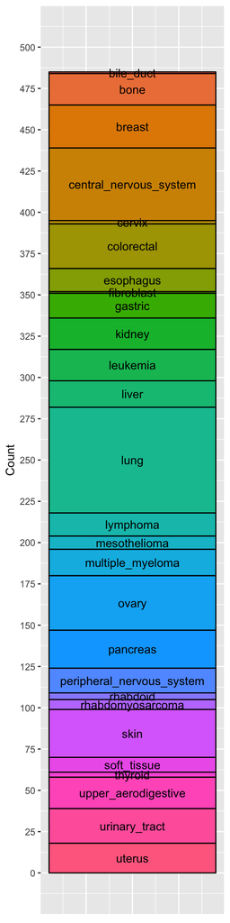

```r
ggplot(data = tissue_summ) +
  aes(x = 0, y = n, fill = primary_tissue, label = primary_tissue) +
  geom_histogram(color = "black", stat = "identity") +
  geom_text(position = position_stack(vjust = 0.5)) +
  scale_y_continuous(breaks = seq(0, 500, by = 25), labels = seq(0, 500, by = 25)) +
  coord_cartesian(ylim = c(0, 500)) +
  theme(legend.position = "none", axis.text.x = element_blank(), axis.ticks.x = element_blank(), axis.title.x = element_blank()) +
  labs(y = "Count")
```

## 7.2 Scores

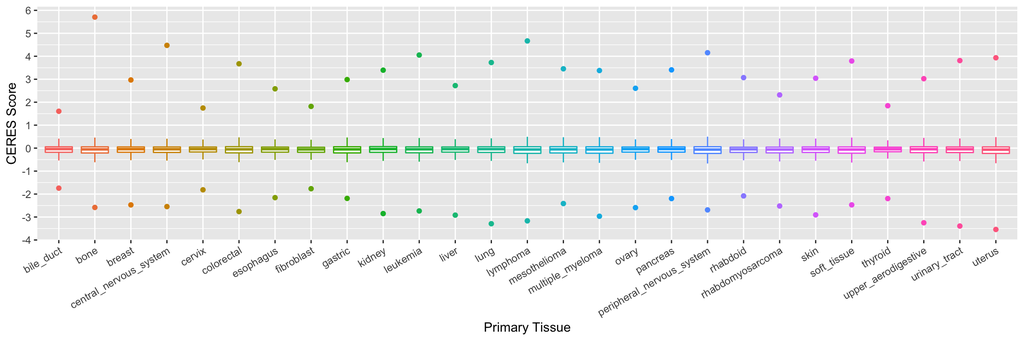

```r
ceres_summ <- crispr_data %>% group_by(primary_tissue) %>% summarize(Max = max(Score),
                                                                     Min = min(Score))
score_summ_plot <- ggplot(data = crispr_data, aes(x = primary_tissue, color = primary_tissue)) +
  geom_boxplot(mapping = aes(y = Score), outlier.shape = NA) +
  geom_point(data = ceres_summ, mapping = aes(x = primary_tissue, y = Min)) +
  geom_point(data = ceres_summ, mapping = aes(x = primary_tissue, y = Max)) +
  scale_y_continuous(breaks = seq(-4, 6, by = 1), labels = seq(-4, 6, by = 1)) +
  theme(axis.text.x = element_text(angle = 30, hjust = 1), legend.position = "none") +
  labs(x = "Primary Tissue", y = "CERES Score")
score_summ_plot
```

```r
# ggsave(filename = "./plots_18Q3/crispr/ceres_score_summ_plot.pdf", plot = score_summ_plot, width = 12, height = 4, device = "pdf")
```

## 7.3 Mutations

```r
maf_df_filt <- filter(maf_df, Hugo_Symbol %in% unique(crispr_data$Hugo_Symbol))
# maf_summ_filt <- maf_df_filt %>% group_by(Mutation_Status) %>% tally()
# maf_summ_filt$Percent <- format(round(maf_summ_filt$n / sum(maf_summ_filt$n) * 100, 4), nsmall = 2)
# maf_summ_filt$Percent <- as.numeric(as.character(maf_summ_filt$Percent))
```

Distribution of mutations across cell lines and primary tissues. Each data point represents a single cell line.

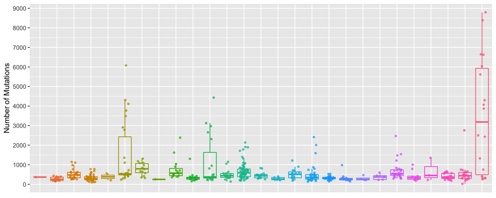

```r
maf_ccl_annot <- merge(maf_df %>% group_by(Broad_ID) %>% tally(), crispr_meta, by = "Broad_ID", all.y = TRUE)

maf_ccl_annot_plot <- ggplot(data = maf_ccl_annot, aes(x = primary_tissue, y = n, color = primary_tissue)) +
  geom_boxplot(outlier.shape = NA, fill = NA) +
  geom_jitter(alpha = 0.7, size = 1, position = position_jitter(w = 0.25)) +
  scale_y_continuous(breaks = seq(0, 9000, by = 1000), labels = seq(0, 9000, by = 1000)) +
  theme(axis.ticks.x = element_blank(), axis.title.x = element_blank(), axis.text.x = element_blank(), legend.position = "none") +
  labs(x = "Primary Tissue", y = "Number of Mutations")
maf_ccl_annot_plot
```

```r
# ggsave(filename = "./plots_18Q3/crispr/maf_ccl_annot_plot.pdf", plot = maf_ccl_annot_plot, width = 12, height = 4, device = "pdf")
```

```r
# ggsave(filename = "./plots_18Q3/crispr/score_mut_summ.pdf", plot = grid.draw(rbind(ggplotGrob(maf_ccl_annot_plot), ggplotGrob(score_summ_plot), size = "first")), width = 12, height = 8, device = "pdf")
```

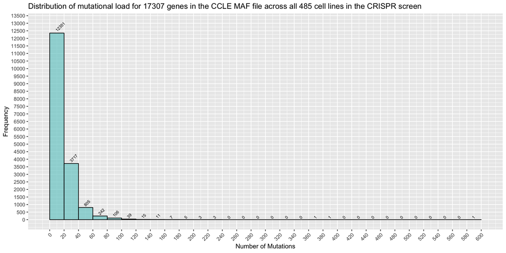

```r
maf_gene_annot <- maf_df_filt %>% group_by(Hugo_Symbol) %>% tally()

ggplot(data = maf_gene_annot, aes(x = n)) +
  geom_histogram(breaks = seq(0, 600, by = 20), fill = "darkslategray3", color = "black", alpha = 0.7) +
  coord_cartesian(ylim = c(0, 13000)) +
  scale_y_continuous(breaks = seq(0, 13500, by = 500), labels = formatC(seq(0, 13500, by = 500), format = "d")) +
  scale_x_continuous(breaks = seq(0, 600, by = 20), labels = seq(0, 600, by = 20)) +
  theme(axis.text.x = element_text(angle = 45, hjust = 1)) +
  stat_bin(breaks = seq(0, 600, by = 20), geom = "text", colour = "black", size = 2.5, aes(label = ..count..), vjust = -0.2, angle = 45, hjust = -0.1) +
  labs(x = "Number of Mutations", y = "Frequency", title = paste0("Distribution of mutational load for ", length(unique(maf_gene_annot$Hugo_Symbol)), " genes in the CCLE MAF file across all ", length(unique(crispr_ccl$Broad_ID)), " cell lines in the CRISPR screen"))
```

## 7.4 Dependency probabilities

```r
drop_prob_100 <- ggplot(data = crispr_data, aes(x = Dep_Prob)) +
  geom_histogram(breaks = seq(0, 1, by = 0.05), fill = "darkslategray3", color = "black", alpha = 0.7) +
  scale_x_continuous(breaks = seq(0, 1, by = 0.05), labels = seq(0, 1, by = 0.05)) +
  scale_y_continuous(breaks = seq(0, 5500000, by = 500000), labels = formatC(seq(0, 5500000, by = 500000), format = "d")) +
  stat_bin(breaks = seq(0, 1, by = 0.05), geom = "text", colour = "black", size = 3.5, aes(label = ..count..), vjust = -1) +
  labs(title = "Distribution of all dependency probabilities", x = "Probability of Real Dependency", y = "Frequency")

dep_prob_5 <- ggplot(data = filter(crispr_data, Dep_Prob >= 0.95), aes(x = Dep_Prob)) +
  geom_histogram(mapping = aes(fill = primary_tissue), breaks = seq(0.95, 1, by = 0.005), color = "black") +
  scale_y_continuous(breaks = seq(0, 60000, by = 10000), labels = formatC(seq(0, 60000, by = 10000), format = "d")) +
  theme(legend.position = "bottom") +
  guides(fill = guide_legend(nrow = 4, byrow = FALSE)) +
  stat_bin(breaks = seq(0.95, 1, by = 0.005), geom = "text", color = "black", size = 3.5, aes(label = ..count..), vjust = -1) +
  labs(title = "Distribution of all dependency probabilities > 0.95", x = "Probability of Real Dependency", y = "Frequency", fill = "Primary Tissue")
```

## 7.5 Per-gene plots

```r
sig_genes <- c("KRAS", "TP53", "NRAS", "BRAF", "PIK3CA", "PTEN", "CTNNB1")
crispr_sig_genes <- filter(crispr_data, Hugo_Symbol %in% sig_genes)
crispr_sig_genes$Hugo_Symbol <- factor(crispr_sig_genes$Hugo_Symbol, levels = c("KRAS", "TP53", "NRAS", "BRAF", "PIK3CA", "PTEN", "CTNNB1"))

crispr_color <- as.character(crispr_sig_genes$Color)
names(crispr_color) <- crispr_sig_genes$Mutation_Status

# Mutation status
plot_mut <- ggplot(data = crispr_sig_genes, aes(x = Mutation_Status, y = Score, color = Mutation_Status)) +
  geom_boxplot(outlier.shape = NA) +
  geom_jitter(alpha = 0.3, size = 0.7, position = position_jitter(w = 0.05)) +
  facet_wrap(~ Hugo_Symbol, nrow = 7, scales = "free_y") +
  scale_color_manual(values = crispr_color) +
  geom_hline(yintercept = 0, linetype = 2, lwd = 0.3) +
  theme_light() +
  theme(legend.position = "none") +
  labs(x = "Mutation Status", y = "CERES Score",
       title = "Mutation Status")
# plot_mut

# Copy number
plot_cn <- ggplot(data = crispr_sig_genes, aes(x = Copy_Number, y = Score, color = Mutation_Status)) +
  geom_point(size = 0.5, alpha = 0.5) +
  geom_smooth(method = "lm", size = 0.5) +
  scale_color_manual(values = crispr_color) +
  facet_wrap(~ Hugo_Symbol, nrow = 7, scales = "free") +
  stat_cor(method = "pearson", show.legend = FALSE, label.x.npc = "right", label.y.npc = "top") +
  theme_light() +
  theme(legend.position = "none", axis.title.y = element_blank()) +
  labs(y = "CERES Score", color = "Mutation Status",
       x = "Theoretical Copy number", title = "Copy Number")
# plot_cn

# Gene expression
plot_ge <- ggplot(data = crispr_sig_genes, aes(x = RPKM_log2, y = Score, color = Mutation_Status)) +
  geom_point(size = 0.5, alpha = 0.5) +
  geom_smooth(method = "lm", size = 0.5) +
  facet_wrap(~ Hugo_Symbol, nrow = 7, scales = "free_y") +
  scale_color_manual(values = crispr_color) +
  stat_cor(method = "pearson", show.legend = FALSE, label.x.npc = "left", label.y.npc = "top") +
  theme_light() +
  theme(legend.position = "none", axis.title.y = element_blank()) +
  labs(y = "CERES Score", color = "Mutation Status",
       x = "Gene Expression [log2(RPKM)]",
       title = "Gene Expression")
# plot_ge

# ggsave(filename = "./plots_18Q3/crispr/omics_sig_genes.pdf", plot = grid.draw(cbind(ggplotGrob(plot_mut), ggplotGrob(plot_ge), ggplotGrob(plot_cn), size = "last")), width = 15, height = 18, device = "pdf")
```